# Creating Customer Segments

- This project will analyze a dataset containing annual spending amounts for internal structure, to understand the variation in the different types of customers that a wholesale distributor interacts with. Given the dataset, it shows monetary consumption for different types of food and supplies; statistical analysis and clustering techniques utilized in this project will be a proxy for approximating the volume of supplies different types of customers buy in addition to uncovering spending patterns of the distributing company's client base.

```python
# Import libraries: NumPy, pandas, matplotlib
import numpy as np
import pandas as pd
import scipy

#Plotting
import matplotlib.pyplot as pl
import matplotlib.cm as cm
%matplotlib inline
import seaborn as sns
sns.set_style("whitegrid")

#Machine Learning Library
from sklearn.decomposition import PCA, FastICA
from sklearn.cluster import KMeans
from sklearn import preprocessing
from sklearn.preprocessing import StandardScaler

#Jupyter Notebook Options
from IPython.display import display


import warnings
warnings.filterwarnings('ignore')
```

### Load Dataset:

```python
data_raw = pd.read_csv("wholesale-customers.csv")
print("Number of Features: %s" % (data_raw.shape[1]))
print("Number of Observations: %s" % (data_raw.shape[0]))

X=data_raw.ix[:,0:6].values
```

```
Number of Features: 6
Number of Observations: 440
```

```python
data_raw.head() #consumption in m.u
```

|  | Fresh | Milk | Grocery | Frozen | Detergents_Paper | Delicatessen |
| --- | --- | --- | --- | --- | --- | --- |
| 0 | 12669 | 9656 | 7561 | 214 | 2674 | 1338 |
| 1 | 7057 | 9810 | 9568 | 1762 | 3293 | 1776 |
| 2 | 6353 | 8808 | 7684 | 2405 | 3516 | 7844 |
| 3 | 13265 | 1196 | 4221 | 6404 | 507 | 1788 |
| 4 | 22615 | 5410 | 7198 | 3915 | 1777 | 5185 |

### Explore the Data:

**1) Before doing any computations, what do you think will show up in your computations? List one or two ideas for what might show up as the first PCA dimensions, or what type of vectors will show up as ICA dimensions.**

- First, Principal Component Analysis (PCA) is utilized to identify patterns in dataset based on the correlation between the n-features. PCA attempts to find the directions of maximum variance in a high-dimensional data (d) and then projects it onto a new subspace (k<=d). The two key insights for PCA is function `data.var()` which illustrates the features that capture the most variance (spread of the data distribution); note that fresh has the highest variance. Also, `data.corr()` since PCA deals with correlation between variables that create the individual eigenvectors. Both of these functions are found in the following PCA section. We would expect the first several PCs to be composed of original attributes that are in some way correlated with each other. These principal components could represent the customers that purchases a combination of items from the wholesale grocery distributor. PCA will be discussed in further detail in the following section.
- Additionally, before running any PCA, plotting the histograms (shown below) could suggest a correlation in the number of orders among `Fresh`, `Milk`, and `Grocery`. Intuitively, the histograms show an exponential decline in the number of orders for the respected products, hence this could perhaps be a cluster consisting of larger size companies with higher purchase quanitites for these particular items. In contrast to the remaining products, the histogram virtually drops off after the first two bins (lower number of orders) and perhaps indicates the smaller sized companies. In addition to `Fresh` and `Grocery` having the highest standard deviations of 12,647 and 9,503 respectively, I would expect these two items to have a high significance (magnitude) in the eigenvector. What we can conclude from the histograms is that the variables have logarithmic distributions, so taking the log of all of the variables would probably give a more normal looking distribution for each variable. A better way of analyzing correlations between two features would be to examine bivariate plots (shown in the PCA section) and observe any linear relationships. For instance, if there is a positive correlation between milk and grocery items, this means that as purchase orders of milk increases, so does grocery items. Similarly, as grocery items increase, so does detergents_paper (resembling a grocery store).
- Independent Component Analysis (ICA) is a statistical technique for identifying the underlying hidden factors for a given multidimensional dataset. In short, ICA produces dimensions of variation where the dimensions (features) are statistically independent from one another. The data variables are assumed to be linear mixtures of some unknown "latent" variables and the mixing system is also unknown. The assumption is that the latent variables are both nongaussian and mutually independent; these variables are called the independent components. In the context of this project we are attempting to identify the different buyer types and cluster them together. Being statistically independent, the different types of buyers could mean the size of the purchaser (small/larger) or different consumption patterns. For example, there are buyers who mostly purchased Milk and Grocery, and less Detergents/Paper or Delicatessen. Likely this could represent the type of purchasers for a small market or convenience store.
- Below is some exploratory data analysis which helps us have an understanding of the data we are working with:

```python
# Descriptive Statistics
data=data_raw
data.describe()
```

|  | Fresh | Milk | Grocery | Frozen | Detergents_Paper | Delicatessen |
| --- | --- | --- | --- | --- | --- | --- |
| count | 440.000000 | 440.000000 | 440.000000 | 440.000000 | 440.000000 | 440.000000 |
| mean | 12000.297727 | 5796.265909 | 7951.277273 | 3071.931818 | 2881.493182 | 1524.870455 |
| std | 12647.328865 | 7380.377175 | 9503.162829 | 4854.673333 | 4767.854448 | 2820.105937 |
| min | 3.000000 | 55.000000 | 3.000000 | 25.000000 | 3.000000 | 3.000000 |
| 25% | 3127.750000 | 1533.000000 | 2153.000000 | 742.250000 | 256.750000 | 408.250000 |
| 50% | 8504.000000 | 3627.000000 | 4755.500000 | 1526.000000 | 816.500000 | 965.500000 |
| 75% | 16933.750000 | 7190.250000 | 10655.750000 | 3554.250000 | 3922.000000 | 1820.250000 |
| max | 112151.000000 | 73498.000000 | 92780.000000 | 60869.000000 | 40827.000000 | 47943.000000 |

[output not shown]

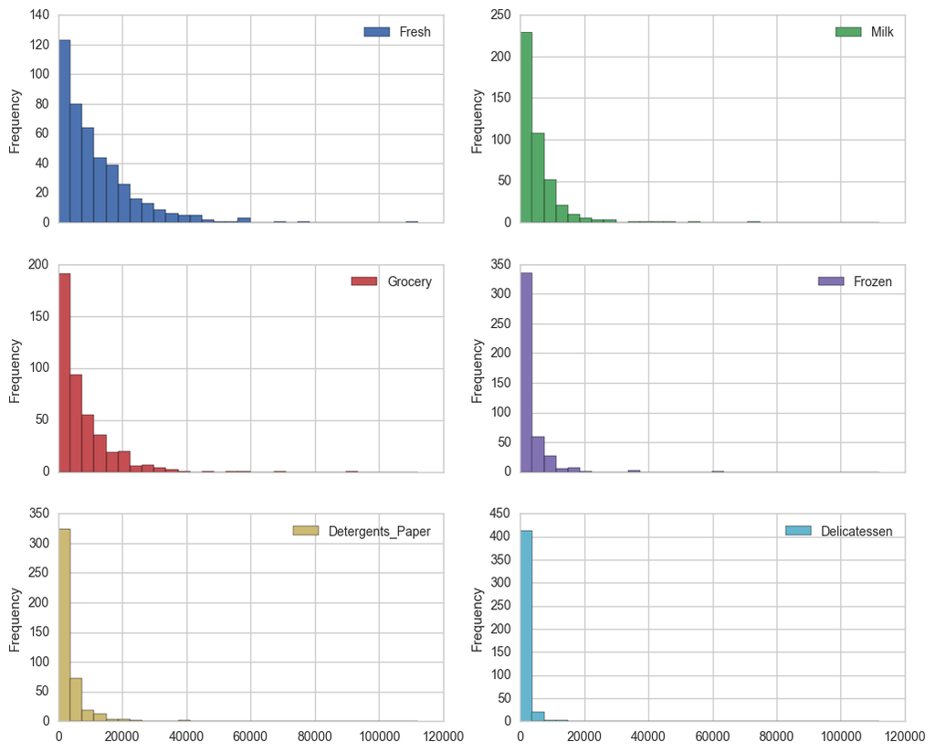

```python
#Histogram
data.plot(kind='hist',bins = 30,
          subplots=True, layout=(3,2), #(rows,columns)
          legend=True, figsize=(12,10))
```

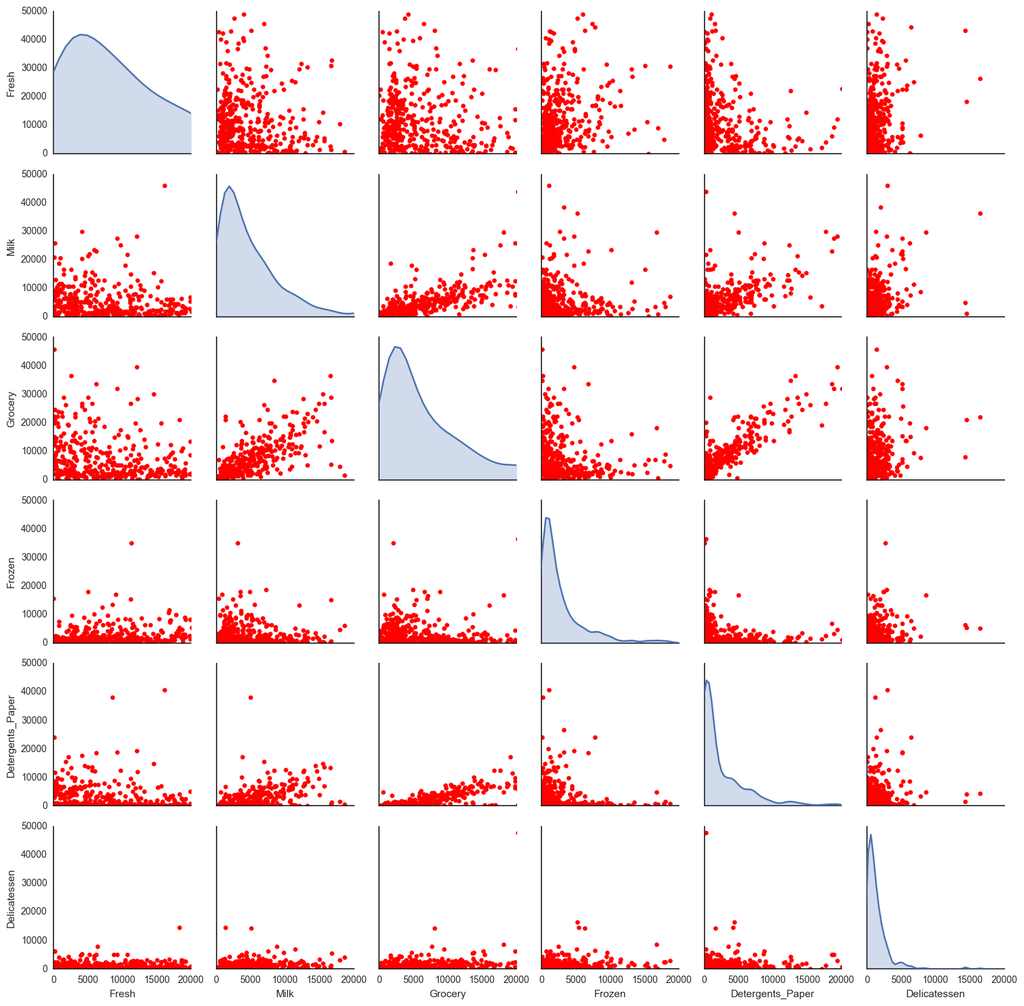

```python
#Scatter Matrix (Original Scale)
g = sns.pairplot(data_raw, diag_kind="kde",markers="o",
        plot_kws=dict(s=20, facecolor="red",edgecolor="red"),
                 diag_kws=dict(shade=True))
g.set(ylim=(0,50000))
g.set(xlim=(0,20000))
```